# FaceNewsIntervention - Data Analysis

## Gender (independent/predictor) & MIST COVID (% Correct pretest) (dependent/outcome)

```r
# Categorical
df$Gender <- as.factor(df$Gender)
m <- lm(MIST_correct_Pretest_covid ~ Gender,
        data=filter(df, Gender != "Non-Binary" & Gender != "Prefer not to answer"))


display(estimate_contrasts(m, contrast="Gender", p_adjust="none"))
```

Marginal Contrasts Analysis

| Level1 | Level2 | Difference | 95% CI | SE | t(258) | p |
| --- | --- | --- | --- | --- | --- | --- |
| Man | Woman | 0.03 | (0.00, 0.07) | 0.02 | 2.13 | 0.034 |

Marginal contrasts estimated at Gender p-values are uncorrected.

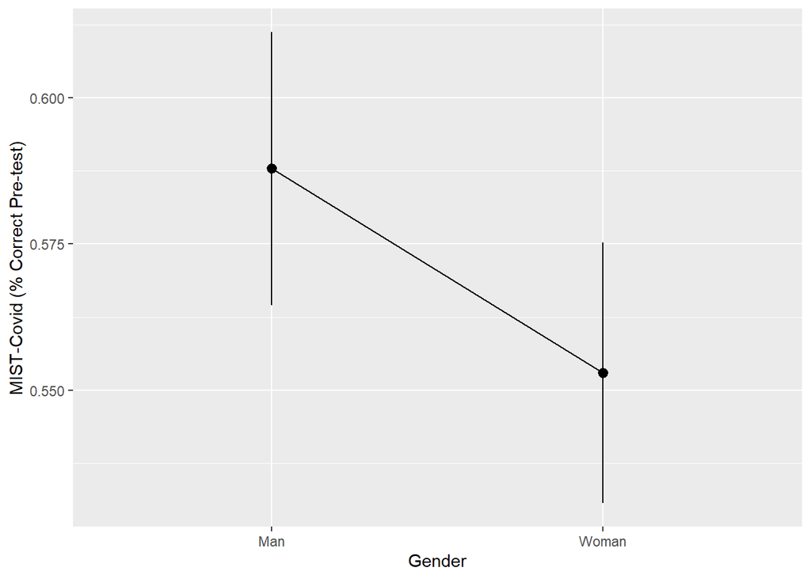

```r
estimate_means(m, by = c("Gender")) |>
  ggplot(aes(x=Gender, y=Mean)) +
  geom_line(aes(group=1)) +
  geom_pointrange(aes(ymin=CI_low, ymax=CI_high)) +
  labs(y="MIST-Covid (% Correct Pre-test)", x="Gender")
```

## Education (independent/predictor) & MIST COVID (% Correct difference post-pre) (dependent/outcome)

```r
# Categorical
df$Education <- as.factor(df$Education)
df <- df %>% filter(!is.na(Education))
unique(trimws(df$Education))
```

```
[1] "Other"       "High School" "Master"      "Bachelor"    "Doctorate"
```

```r
m <- lm(MIST_correct_Diff_covid ~ Education,
        data=filter(df, Education != "Other"))

display(estimate_contrasts(m, contrast="Education", p_adjust="none"))
```

Marginal Contrasts Analysis

| Level1 | Level2 | Difference | 95% CI | SE | t(245) | p |
| --- | --- | --- | --- | --- | --- | --- |
| Bachelor | Doctorate | -0.06 | (-0.20, 0.07) | 0.07 | -0.90 | 0.371 |
| Bachelor | High School | 0.04 | (-0.01, 0.10) | 0.03 | 1.45 | 0.150 |
| Bachelor | Master | 0.05 | (-0.02, 0.13) | 0.04 | 1.50 | 0.136 |
| Doctorate | High School | 0.10 | (-0.03, 0.24) | 0.07 | 1.51 | 0.132 |
| Doctorate | Master | 0.12 | (-0.03, 0.26) | 0.07 | 1.62 | 0.107 |
| High School | Master | 0.01 | (-0.05, 0.08) | 0.03 | 0.38 | 0.704 |

Marginal contrasts estimated at Education p-values are uncorrected.

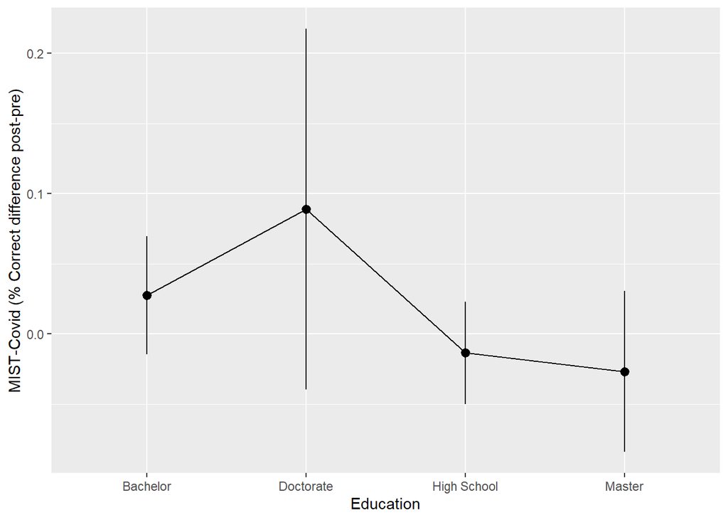

```r
estimate_means(m, by = c("Education")) |>
  ggplot(aes(x=Education, y=Mean)) +
  geom_line(aes(group=1)) +
  geom_pointrange(aes(ymin=CI_low, ymax=CI_high)) +
  labs(y="MIST-Covid (% Correct difference post-pre)", x="Education")
```

## Education (independent/predictor) & MIST COVID (% Correct pretest) (dependent/outcome)

```r
# Categorical
df$Education <- as.factor(df$Education)
m <- lm(MIST_correct_Pretest_covid ~ Education,
        data=filter(df, Education != "Other"))

display(estimate_contrasts(m, contrast="Education", p_adjust="none"))
```

Marginal Contrasts Analysis

| Level1 | Level2 | Difference | 95% CI | SE | t(245) | p |
| --- | --- | --- | --- | --- | --- | --- |
| Bachelor | Doctorate | 0.01 | (-0.08, 0.11) | 0.05 | 0.21 | 0.831 |
| Bachelor | High School | -0.03 | (-0.07, 0.01) | 0.02 | -1.55 | 0.123 |
| Bachelor | Master | -0.01 | (-0.06, 0.04) | 0.03 | -0.47 | 0.640 |
| Doctorate | High School | -0.04 | (-0.14, 0.05) | 0.05 | -0.86 | 0.390 |
| Doctorate | Master | -0.02 | (-0.12, 0.08) | 0.05 | -0.44 | 0.659 |
| High School | Master | 0.02 | (-0.03, 0.07) | 0.02 | 0.78 | 0.438 |

Marginal contrasts estimated at Education p-values are uncorrected.

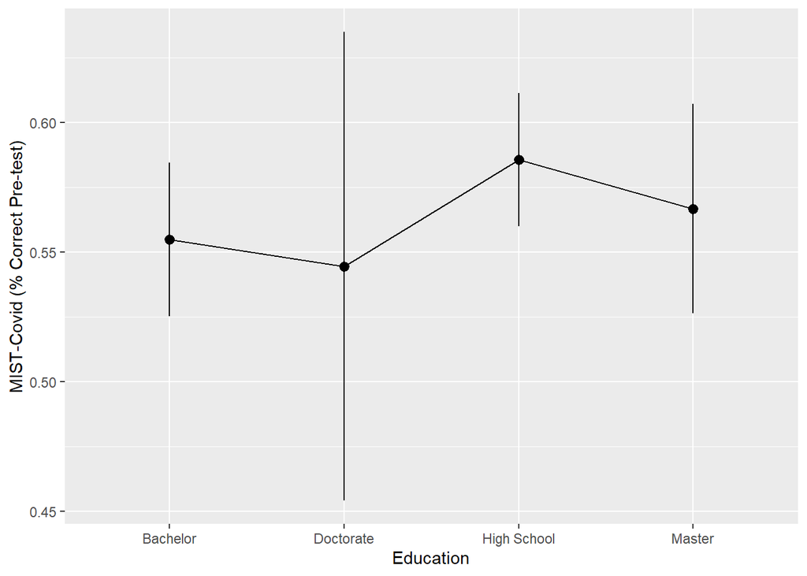

```r
estimate_means(m, by = c("Education")) |>
  ggplot(aes(x=Education, y=Mean)) +
  geom_line(aes(group=1)) +
  geom_pointrange(aes(ymin=CI_low, ymax=CI_high)) +
  labs(y="MIST-Covid (% Correct Pre-test)", x="Education")
```

## Age (independent/predictor) & MIST COVID (% Correct pretest) (dependent/outcome)

```r
m <- lm(MIST_correct_Pretest_covid ~ Age,
        data=df)

display(parameters(m))
```

| Parameter | Coefficient | SE | 95% CI | t(263) | p |
| --- | --- | --- | --- | --- | --- |
| (Intercept) | 0.60 | 0.02 | (0.55, 0.64) | 23.84 | < .001 |
| Age | -5.55e-04 | 5.21e-04 | (-1.58e-03, 4.71e-04) | -1.07 | 0.288 |

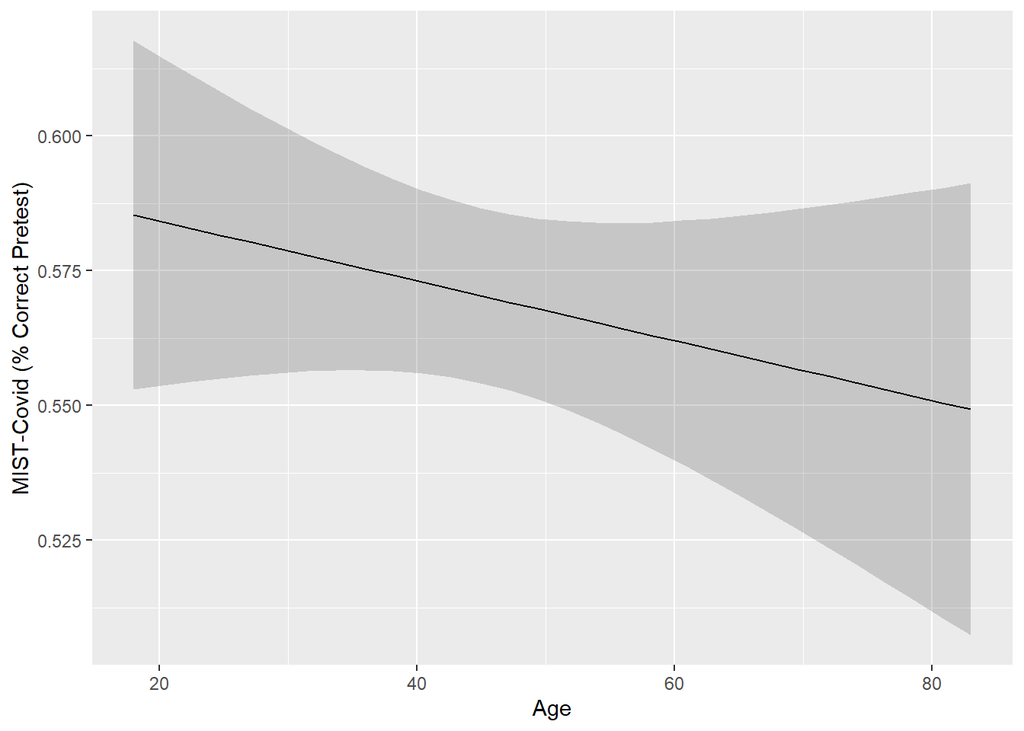

```r
estimate_relation(m, length=30) |>
  ggplot(aes(x=Age, y=Predicted)) +
  # geom_jitter(data=filter(df, !is.na(Political_LiberalConservative)),
  #             aes(y=MIST_correct_Pretest_covid), alpha=0.2, size=3) +
  geom_ribbon(aes(ymin=CI_low, ymax=CI_high), alpha=0.2) +
  geom_line() +
  labs(y="MIST-Covid (% Correct Pretest)", x="Age")
```

## Age (independent/predictor) & MIST COVID (% Correct difference post-pre) (dependent/outcome)

## why does this one show essentially no change in intervention effect size whatsoever? Feels like I made a mistake here somewhere

```r
m <- lm(MIST_correct_Diff_covid ~ Age,
        data=df)

display(parameters(m))
```

| Parameter | Coefficient | SE | 95% CI | t(263) | p |
| --- | --- | --- | --- | --- | --- |
| (Intercept) | 0.02 | 0.04 | (-0.05, 0.09) | 0.45 | 0.656 |
| Age | -3.19e-04 | 7.47e-04 | (-1.79e-03, 1.15e-03) | -0.43 | 0.669 |

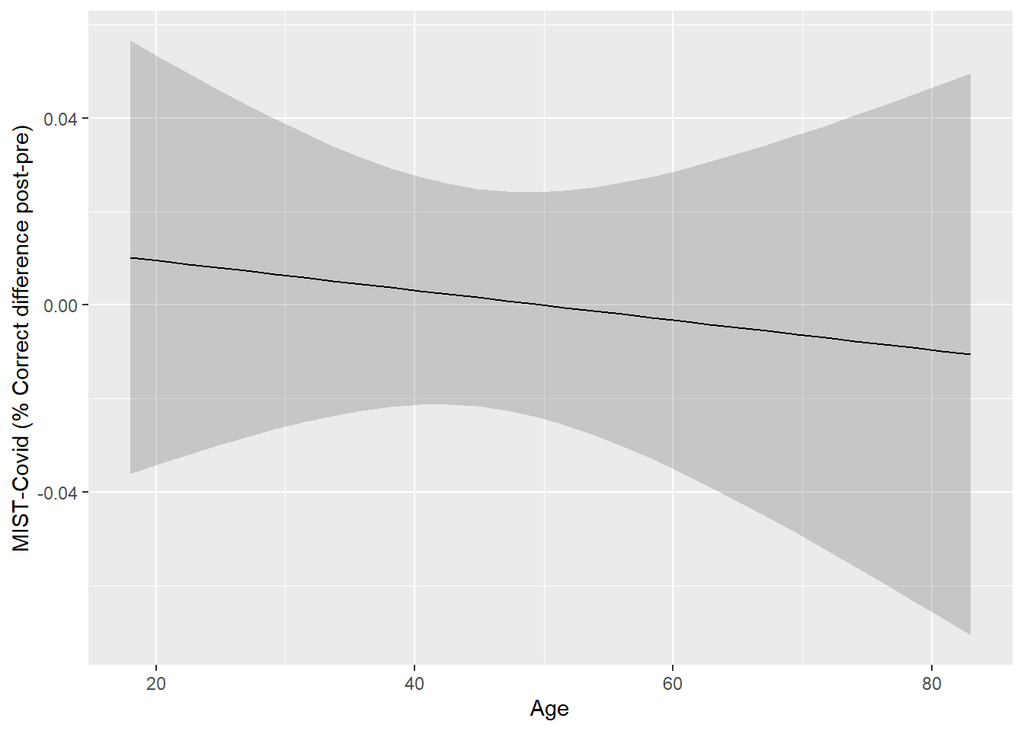

```r
estimate_relation(m, length=30) |>
  ggplot(aes(x=Age, y=Predicted)) +
  # geom_jitter(data=filter(df, !is.na(Political_LiberalConservative)),
  #             aes(y=MIST_correct_Pretest_covid), alpha=0.2, size=3) +
  geom_ribbon(aes(ymin=CI_low, ymax=CI_high), alpha=0.2) +
  geom_line() +
  labs(y="MIST-Covid (% Correct difference post-pre)", x="Age")
```

## Intervention vs Control (independent/predictor) & MOCRI (% Correct difference post-pre) (dependent/outcome)

```r
# Categorical
m <- lm(MOCRI_correct_Diff ~ Intervention,
        data=df)

display(estimate_contrasts(m, contrast="Intervention", p_adjust="none"))
```

Marginal Contrasts Analysis

| Level1 | Level2 | Difference | 95% CI | SE | t(264) | p |
| --- | --- | --- | --- | --- | --- | --- |
| Tetris | BadNews | -9.01e-04 | (-0.03, 0.03) | 0.02 | -0.06 | 0.952 |

Marginal contrasts estimated at Intervention p-values are uncorrected.

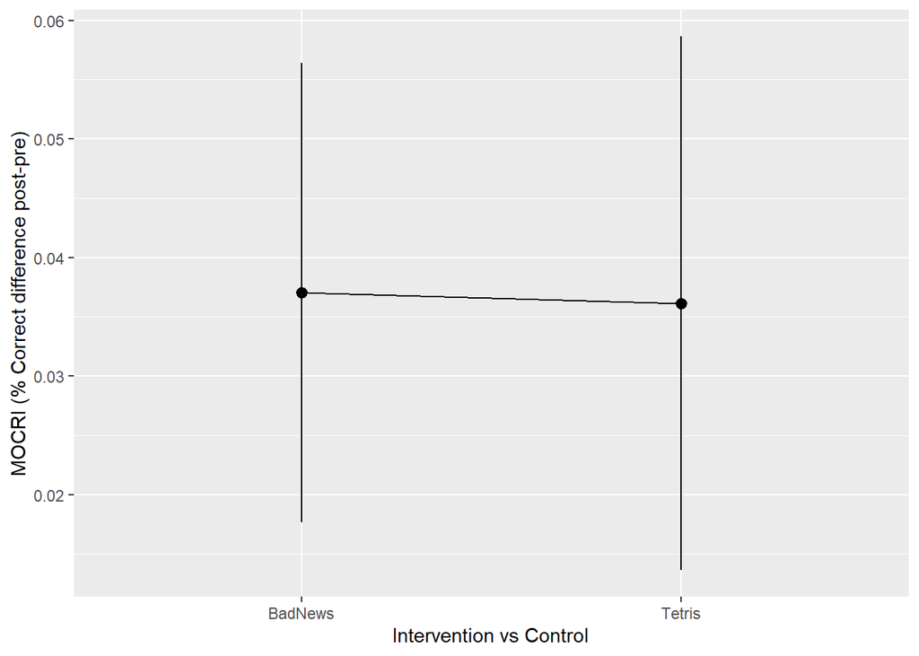

```r
estimate_means(m, by = "Intervention") |>
  ggplot(aes(x=Intervention, y=Mean)) +
  geom_line(aes(group=1)) +
  geom_pointrange(aes(ymin=CI_low, ymax=CI_high)) +
  labs(y="MOCRI (% Correct difference post-pre)", x="Intervention vs Control")
```

## Intervention vs Control (independent/predictor) & MOCRI (% dprime difference post-pre) (dependent/outcome)

```r
# Categorical
m <- lm(MOCRI_dprime_Diff ~ Intervention,
        data=df)

display(estimate_contrasts(m, contrast="Intervention", p_adjust="none"))
```

Marginal Contrasts Analysis

| Level1 | Level2 | Difference | 95% CI | SE | t(264) | p |
| --- | --- | --- | --- | --- | --- | --- |
| Tetris | BadNews | 0.11 | (-0.15, 0.37) | 0.13 | 0.84 | 0.403 |

Marginal contrasts estimated at Intervention p-values are uncorrected.

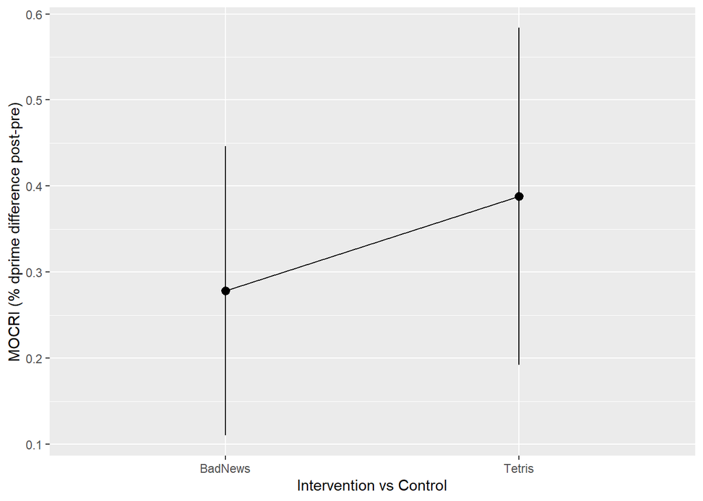

```r
estimate_means(m, by = "Intervention") |>
  ggplot(aes(x=Intervention, y=Mean)) +
  geom_line(aes(group=1)) +
  geom_pointrange(aes(ymin=CI_low, ymax=CI_high)) +
  labs(y="MOCRI (% dprime difference post-pre)", x="Intervention vs Control")
```

## Intervention vs Control (independent/predictor) & MIST COVID (% Correct difference post-pre) (dependent/outcome)

```r
# Categorical
m <- lm(MIST_correct_Diff_covid ~ Intervention,
        data=df)

display(estimate_contrasts(m, contrast="Intervention", p_adjust="none"))
```

Marginal Contrasts Analysis

| Level1 | Level2 | Difference | 95% CI | SE | t(264) | p |
| --- | --- | --- | --- | --- | --- | --- |
| Tetris | BadNews | -0.06 | (-0.10, -0.01) | 0.02 | -2.42 | 0.016 |

Marginal contrasts estimated at Intervention p-values are uncorrected.

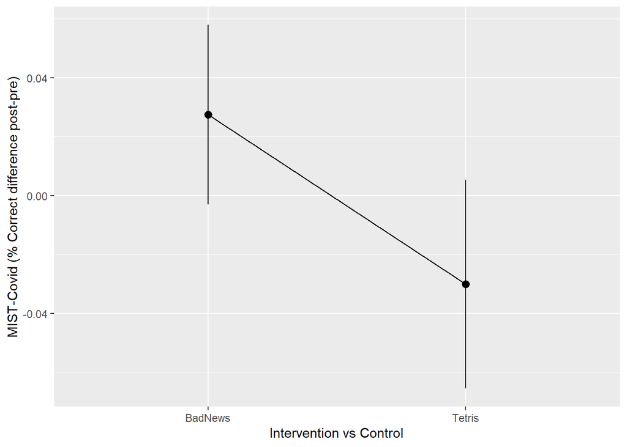

```r
estimate_means(m, by = "Intervention") |>
  ggplot(aes(x=Intervention, y=Mean)) +
  geom_line(aes(group=1)) +
  geom_pointrange(aes(ymin=CI_low, ymax=CI_high)) +
  labs(y="MIST-Covid (% Correct difference post-pre)", x="Intervention vs Control")
```

## Intervention vs Control (independent/predictor) & MIST COVID (dprime difference post-pre) (dependent/outcome)

```r
# Categorical
m <- lm(MIST_dprime_Diff_covid ~ Intervention,
        data=df)

display(estimate_contrasts(m, contrast="Intervention", p_adjust="none"))
```

Marginal Contrasts Analysis

| Level1 | Level2 | Difference | 95% CI | SE | t(264) | p |
| --- | --- | --- | --- | --- | --- | --- |
| Tetris | BadNews | -0.32 | (-0.57, -0.06) | 0.13 | -2.46 | 0.014 |

Marginal contrasts estimated at Intervention p-values are uncorrected.

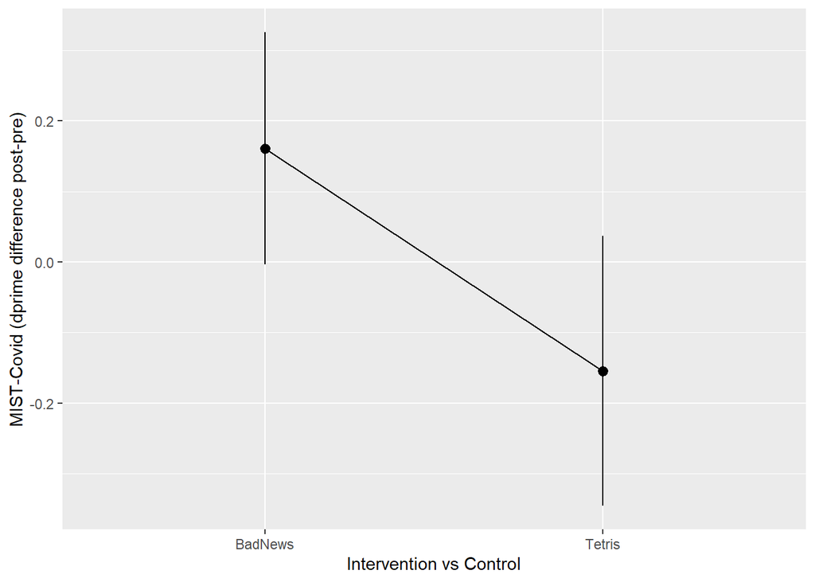

```r
estimate_means(m, by = "Intervention") |>
  ggplot(aes(x=Intervention, y=Mean)) +
  geom_line(aes(group=1)) +
  geom_pointrange(aes(ymin=CI_low, ymax=CI_high)) +
  labs(y="MIST-Covid (dprime difference post-pre)", x="Intervention vs Control")
```

## Intervention vs Control (independent/predictor) & MIST general (% Correct difference post-pre) (dependent/outcome)

```r
# Categorical
m <- lm(MIST_correct_Diff_general ~ Intervention,
        data=df)

display(estimate_contrasts(m, contrast="Intervention", p_adjust="none"))
```

Marginal Contrasts Analysis

| Level1 | Level2 | Difference | 95% CI | SE | t(264) | p |
| --- | --- | --- | --- | --- | --- | --- |
| Tetris | BadNews | -0.03 | (-0.06, 0.00) | 0.01 | -1.88 | 0.061 |

Marginal contrasts estimated at Intervention p-values are uncorrected.

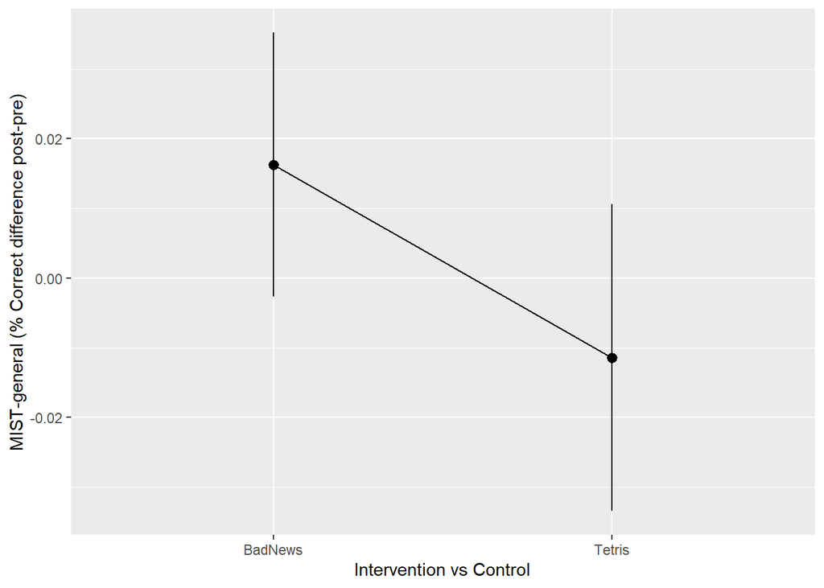

```r
estimate_means(m, by = "Intervention") |>
  ggplot(aes(x=Intervention, y=Mean)) +
  geom_line(aes(group=1)) +
  geom_pointrange(aes(ymin=CI_low, ymax=CI_high)) +
  labs(y="MIST-general (% Correct difference post-pre)", x="Intervention vs Control")
```

## Intervention vs Control (independent/predictor) & MIST general (dprime difference post-pre) (dependent/outcome)

```r
# Categorical
m <- lm(MIST_dprime_Diff_general ~ Intervention,
        data=df)

display(estimate_contrasts(m, contrast="Intervention", p_adjust="none"))
```

Marginal Contrasts Analysis

| Level1 | Level2 | Difference | 95% CI | SE | t(264) | p |
| --- | --- | --- | --- | --- | --- | --- |
| Tetris | BadNews | -0.19 | (-0.37, -0.01) | 0.09 | -2.13 | 0.034 |

Marginal contrasts estimated at Intervention p-values are uncorrected.

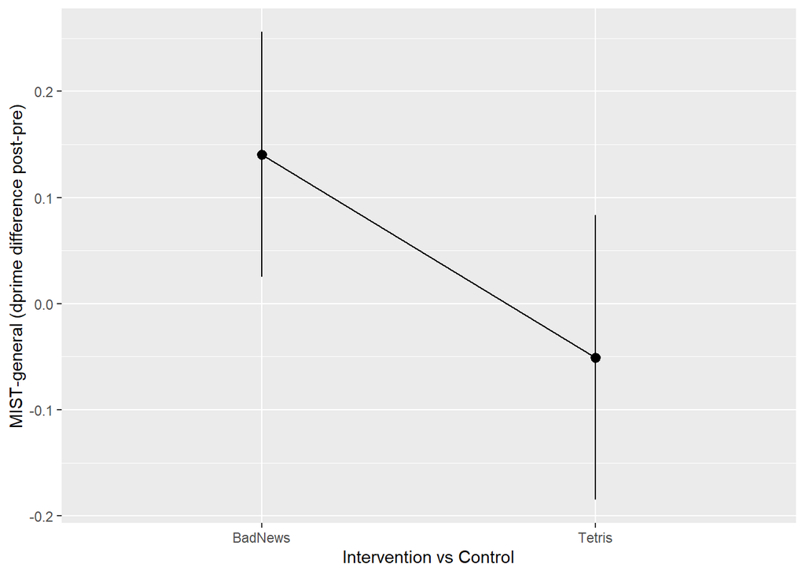

```r
estimate_means(m, by = "Intervention") |>
  ggplot(aes(x=Intervention, y=Mean)) +
  geom_line(aes(group=1)) +
  geom_pointrange(aes(ymin=CI_low, ymax=CI_high)) +
  labs(y="MIST-general (dprime difference post-pre)", x="Intervention vs Control")
```

## Intervention vs Control (independent/predictor) & MIST total (% Correct difference post-pre) (dependent/outcome)

```r
# Categorical
m <- lm(MIST_correct_Diff ~ Intervention,
        data=df)

display(estimate_contrasts(m, contrast="Intervention", p_adjust="none"))
```

Marginal Contrasts Analysis

| Level1 | Level2 | Difference | 95% CI | SE | t(264) | p |
| --- | --- | --- | --- | --- | --- | --- |
| Tetris | BadNews | -0.04 | (-0.07, -0.01) | 0.01 | -2.96 | 0.003 |

Marginal contrasts estimated at Intervention p-values are uncorrected.

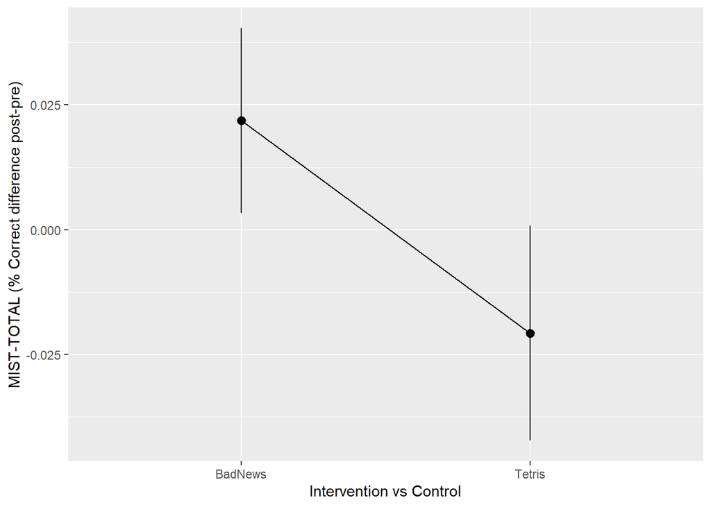

```r
estimate_means(m, by = "Intervention") |>
  ggplot(aes(x=Intervention, y=Mean)) +
  geom_line(aes(group=1)) +
  geom_pointrange(aes(ymin=CI_low, ymax=CI_high)) +
  labs(y="MIST-TOTAL (% Correct difference post-pre)", x="Intervention vs Control")
```

## Intervention vs Control (independent/predictor) & MIST total (dprime difference post-pre) (dependent/outcome)

```r
# Categorical
m <- lm(MIST_dprime_Diff ~ Intervention,
        data=df)

display(estimate_contrasts(m, contrast="Intervention", p_adjust="none"))
```

Marginal Contrasts Analysis

| Level1 | Level2 | Difference | 95% CI | SE | t(264) | p |
| --- | --- | --- | --- | --- | --- | --- |
| Tetris | BadNews | -0.25 | (-0.41, -0.10) | 0.08 | -3.15 | 0.002 |

Marginal contrasts estimated at Intervention p-values are uncorrected.

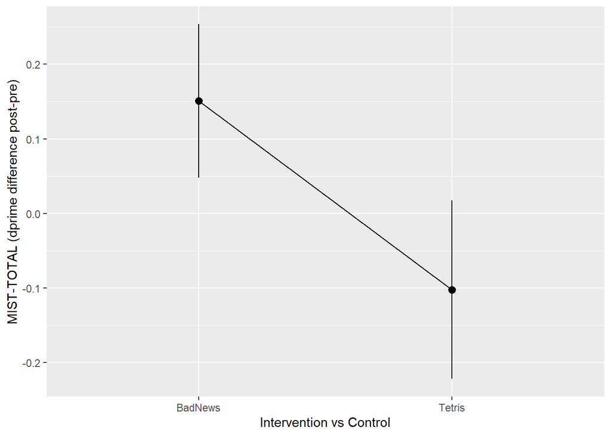

```r
estimate_means(m, by = "Intervention") |>
  ggplot(aes(x=Intervention, y=Mean)) +
  geom_line(aes(group=1)) +
  geom_pointrange(aes(ymin=CI_low, ymax=CI_high)) +
  labs(y="MIST-TOTAL (dprime difference post-pre)", x="Intervention vs Control")
```

## ONLY SELF-IDENTIFIED REPUBLICANS [party affiliation] Intervention vs Control (independent/predictor) & MOCRI (% Correct difference post-pre) (dependent/outcome)

```r
df_republicans <- df[df$Political_Affiliation == "Republican", ]

m <- lm(MOCRI_correct_Diff ~ Intervention,
        data=df_republicans)

display(estimate_contrasts(m, contrast="Intervention", p_adjust="none"))
```

Marginal Contrasts Analysis

| Level1 | Level2 | Difference | 95% CI | SE | t(80) | p |
| --- | --- | --- | --- | --- | --- | --- |
| Tetris | BadNews | 0.02 | (-0.04, 0.07) | 0.03 | 0.55 | 0.583 |

Marginal contrasts estimated at Intervention p-values are uncorrected.

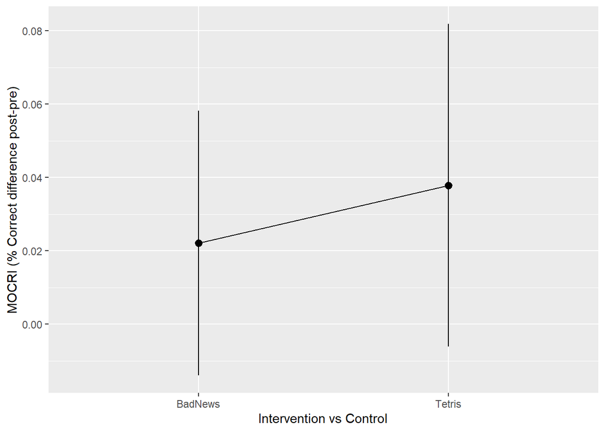

```r
estimate_means(m, by = "Intervention") |>
  ggplot(aes(x=Intervention, y=Mean)) +
  geom_line(aes(group=1)) +
  geom_pointrange(aes(ymin=CI_low, ymax=CI_high)) +
  labs(y="MOCRI (% Correct difference post-pre)", x="Intervention vs Control")
```

## ONLY SELF-IDENTIFIED REPUBLICANS [party affiliation] Intervention vs Control (independent/predictor) & MOCRI (dprime difference post-pre) (dependent/outcome)

```r
df_republicans <- df[df$Political_Affiliation == "Republican", ]

m <- lm(MOCRI_dprime_Diff ~ Intervention,
        data=df_republicans)

display(estimate_contrasts(m, contrast="Intervention", p_adjust="none"))
```

Marginal Contrasts Analysis

| Level1 | Level2 | Difference | 95% CI | SE | t(80) | p |
| --- | --- | --- | --- | --- | --- | --- |
| Tetris | BadNews | 0.24 | (-0.25, 0.74) | 0.25 | 0.99 | 0.325 |

Marginal contrasts estimated at Intervention p-values are uncorrected.

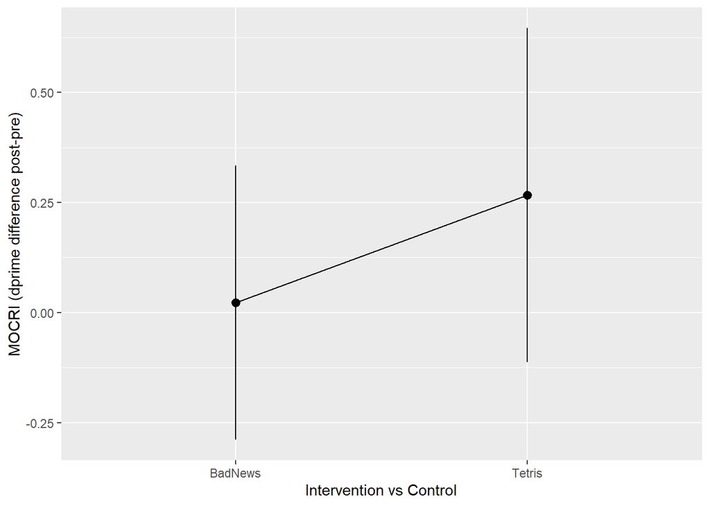

```r
estimate_means(m, by = "Intervention") |>
  ggplot(aes(x=Intervention, y=Mean)) +
  geom_line(aes(group=1)) +
  geom_pointrange(aes(ymin=CI_low, ymax=CI_high)) +
  labs(y="MOCRI (dprime difference post-pre)", x="Intervention vs Control")
```

## ONLY SELF-IDENTIFIED REPUBLICANS [party affiliation] Intervention vs Control (independent/predictor) & MIST COVID (% Correct difference post-pre) (dependent/outcome)

```r
df_republicans <- df[df$Political_Affiliation == "Republican", ]

m <- lm(MIST_correct_Diff_covid ~ Intervention,
        data=df_republicans)

display(estimate_contrasts(m, contrast="Intervention", p_adjust="none"))
```

Marginal Contrasts Analysis

| Level1 | Level2 | Difference | 95% CI | SE | t(80) | p |
| --- | --- | --- | --- | --- | --- | --- |
| Tetris | BadNews | -0.10 | (-0.18, -0.02) | 0.04 | -2.36 | 0.021 |

Marginal contrasts estimated at Intervention p-values are uncorrected.

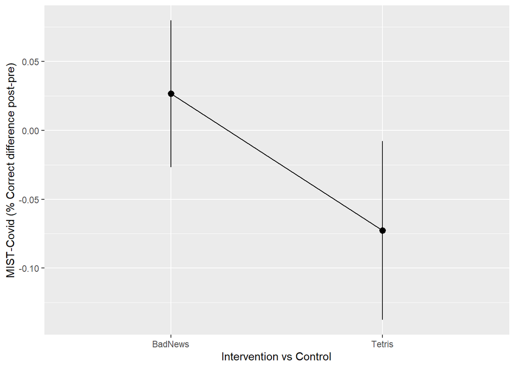

```r
estimate_means(m, by = "Intervention") |>
  ggplot(aes(x=Intervention, y=Mean)) +
  geom_line(aes(group=1)) +
  geom_pointrange(aes(ymin=CI_low, ymax=CI_high)) +
  labs(y="MIST-Covid (% Correct difference post-pre)", x="Intervention vs Control")
```

## ONLY SELF-IDENTIFIED REPUBLICANS [party affiliation] Intervention vs Control (independent/predictor) & MIST COVID (dprime difference post-pre) (dependent/outcome)

```r
df_republicans <- df[df$Political_Affiliation == "Republican", ]

m <- lm(MIST_dprime_Diff_covid ~ Intervention,
        data=df_republicans)

display(estimate_contrasts(m, contrast="Intervention", p_adjust="none"))
```

Marginal Contrasts Analysis

| Level1 | Level2 | Difference | 95% CI | SE | t(80) | p |
| --- | --- | --- | --- | --- | --- | --- |
| Tetris | BadNews | -0.52 | (-0.97, -0.08) | 0.22 | -2.34 | 0.022 |

Marginal contrasts estimated at Intervention p-values are uncorrected.

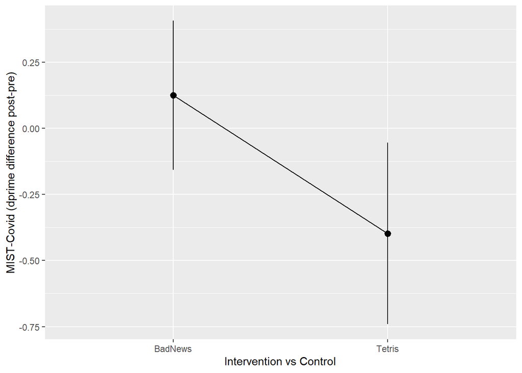

```r
estimate_means(m, by = "Intervention") |>
  ggplot(aes(x=Intervention, y=Mean)) +
  geom_line(aes(group=1)) +
  geom_pointrange(aes(ymin=CI_low, ymax=CI_high)) +
  labs(y="MIST-Covid (dprime difference post-pre)", x="Intervention vs Control")
```

## ONLY SELF-IDENTIFIED REPUBLICANS [party affiliation] Intervention vs Control (independent/predictor) & MIST GENERAL (% Correct difference post-pre) (dependent/outcome)

```r
df_republicans <- df[df$Political_Affiliation == "Republican", ]

m <- lm(MIST_correct_Diff_general ~ Intervention,
        data=df_republicans)

display(estimate_contrasts(m, contrast="Intervention", p_adjust="none"))
```

Marginal Contrasts Analysis

| Level1 | Level2 | Difference | 95% CI | SE | t(80) | p |
| --- | --- | --- | --- | --- | --- | --- |
| Tetris | BadNews | -6.14e-03 | (-0.06, 0.05) | 0.03 | -0.24 | 0.814 |

Marginal contrasts estimated at Intervention p-values are uncorrected.

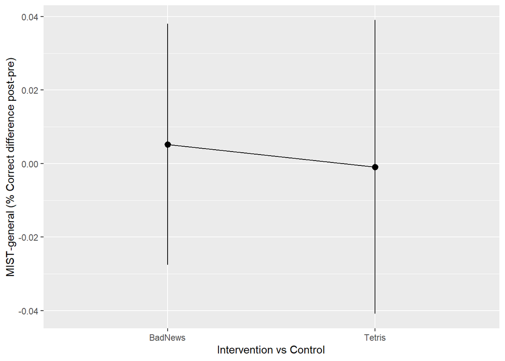

```r
estimate_means(m, by = "Intervention") |>
  ggplot(aes(x=Intervention, y=Mean)) +
  geom_line(aes(group=1)) +
  geom_pointrange(aes(ymin=CI_low, ymax=CI_high)) +
  labs(y="MIST-general (% Correct difference post-pre)", x="Intervention vs Control")
```

## ONLY SELF-IDENTIFIED REPUBLICANS [party affiliation] Intervention vs Control (independent/predictor) & MIST GENERAL (dprime difference post-pre) (dependent/outcome)

```r
df_republicans <- df[df$Political_Affiliation == "Republican", ]

m <- lm(MIST_dprime_Diff_general ~ Intervention,
        data=df_republicans)

display(estimate_contrasts(m, contrast="Intervention", p_adjust="none"))
```

Marginal Contrasts Analysis

| Level1 | Level2 | Difference | 95% CI | SE | t(80) | p |
| --- | --- | --- | --- | --- | --- | --- |
| Tetris | BadNews | -0.03 | (-0.35, 0.28) | 0.16 | -0.21 | 0.832 |

Marginal contrasts estimated at Intervention p-values are uncorrected.

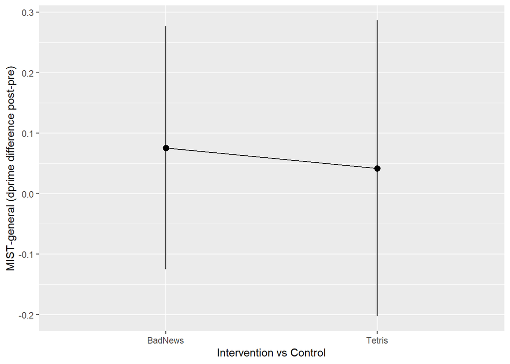

```r
estimate_means(m, by = "Intervention") |>
  ggplot(aes(x=Intervention, y=Mean)) +
  geom_line(aes(group=1)) +
  geom_pointrange(aes(ymin=CI_low, ymax=CI_high)) +
  labs(y="MIST-general (dprime difference post-pre)", x="Intervention vs Control")
```

## ONLY SELF-IDENTIFIED REPUBLICANS [party affiliation] Intervention vs Control (independent/predictor) & MIST TOTAL (% Correct difference post-pre) (dependent/outcome)

```r
df_republicans <- df[df$Political_Affiliation == "Republican", ]

m <- lm(MIST_correct_Diff ~ Intervention,
        data=df_republicans)

display(estimate_contrasts(m, contrast="Intervention", p_adjust="none"))
```

Marginal Contrasts Analysis

| Level1 | Level2 | Difference | 95% CI | SE | t(80) | p |
| --- | --- | --- | --- | --- | --- | --- |
| Tetris | BadNews | -0.05 | (-0.10, 0.00) | 0.03 | -2.04 | 0.044 |

Marginal contrasts estimated at Intervention p-values are uncorrected.

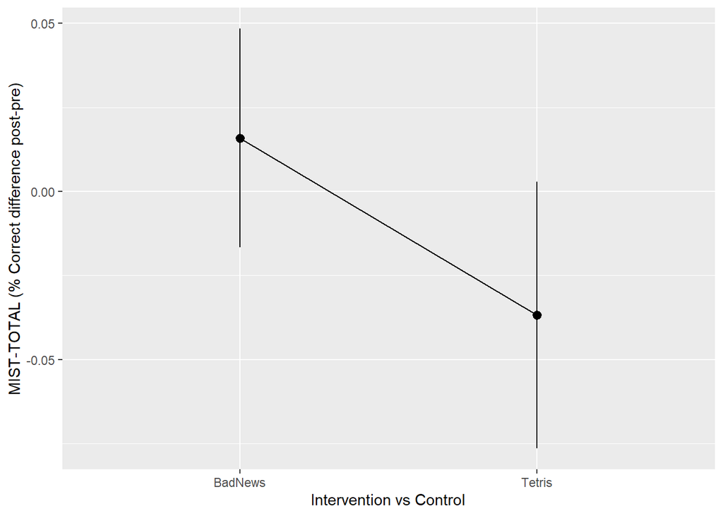

```r
estimate_means(m, by = "Intervention") |>
  ggplot(aes(x=Intervention, y=Mean)) +
  geom_line(aes(group=1)) +
  geom_pointrange(aes(ymin=CI_low, ymax=CI_high)) +
  labs(y="MIST-TOTAL (% Correct difference post-pre)", x="Intervention vs Control")
```

## ONLY SELF-IDENTIFIED REPUBLICANS [party affiliation] Intervention vs Control (independent/predictor) & MIST TOTAL (dprime difference post-pre) (dependent/outcome)

```r
df_republicans <- df[df$Political_Affiliation == "Republican", ]

m <- lm(MIST_dprime_Diff ~ Intervention,
        data=df_republicans)

display(estimate_contrasts(m, contrast="Intervention", p_adjust="none"))
```

Marginal Contrasts Analysis

| Level1 | Level2 | Difference | 95% CI | SE | t(80) | p |
| --- | --- | --- | --- | --- | --- | --- |
| Tetris | BadNews | -0.28 | (-0.56, 0.00) | 0.14 | -1.99 | 0.050 |

Marginal contrasts estimated at Intervention p-values are uncorrected.

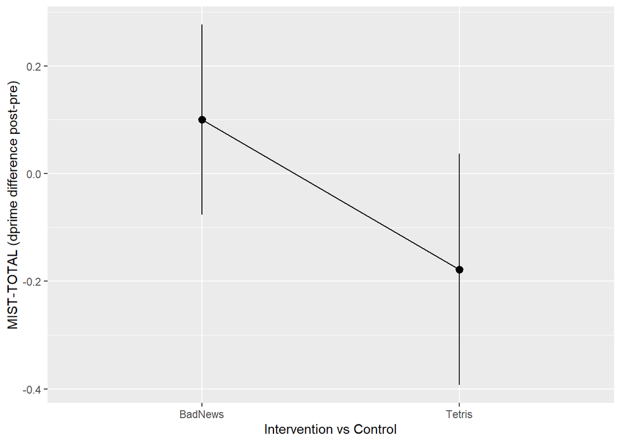

```r
estimate_means(m, by = "Intervention") |>
  ggplot(aes(x=Intervention, y=Mean)) +
  geom_line(aes(group=1)) +
  geom_pointrange(aes(ymin=CI_low, ymax=CI_high)) +
  labs(y="MIST-TOTAL (dprime difference post-pre)", x="Intervention vs Control")
```

## ONLY SELF-IDENTIFIED CONSERVATIVES [ideology affiliation] Intervention vs Control (independent/predictor) & MIST COVID (% Correct difference post-pre) (dependent/outcome)

```r
df_conservatives <- df[df$Political_LiberalConservative >= 5 & df$Political_LiberalConservative <= 7, ]

m <- lm(MIST_correct_Diff_covid ~ Intervention,
        data=df_conservatives)

display(estimate_contrasts(m, contrast="Intervention", p_adjust="none"))
```

Marginal Contrasts Analysis

| Level1 | Level2 | Difference | 95% CI | SE | t(54) | p |
| --- | --- | --- | --- | --- | --- | --- |
| Tetris | BadNews | -0.12 | (-0.23, -0.01) | 0.06 | -2.19 | 0.033 |

Marginal contrasts estimated at Intervention p-values are uncorrected.

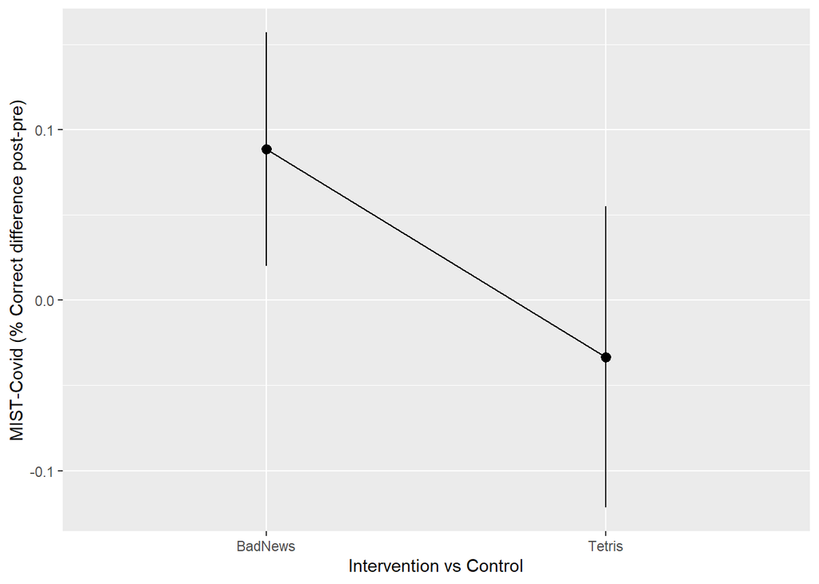

```r
estimate_means(m, by = "Intervention") |>
  ggplot(aes(x=Intervention, y=Mean)) +
  geom_line(aes(group=1)) +
  geom_pointrange(aes(ymin=CI_low, ymax=CI_high)) +
  labs(y="MIST-Covid (% Correct difference post-pre)", x="Intervention vs Control")
```

## ONLY SELF-IDENTIFIED CONSERVATIVES [ideology affiliation] Intervention vs Control (independent/predictor) & MIST General (% Correct difference post-pre) (dependent/outcome)

```r
df_conservatives <- df[df$Political_LiberalConservative >= 5 & df$Political_LiberalConservative <= 7, ]

m <- lm(MIST_correct_Diff_general ~ Intervention,
        data=df_conservatives)

display(estimate_contrasts(m, contrast="Intervention", p_adjust="none"))
```

Marginal Contrasts Analysis

| Level1 | Level2 | Difference | 95% CI | SE | t(54) | p |
| --- | --- | --- | --- | --- | --- | --- |
| Tetris | BadNews | -0.02 | (-0.09, 0.05) | 0.03 | -0.67 | 0.508 |

Marginal contrasts estimated at Intervention p-values are uncorrected.

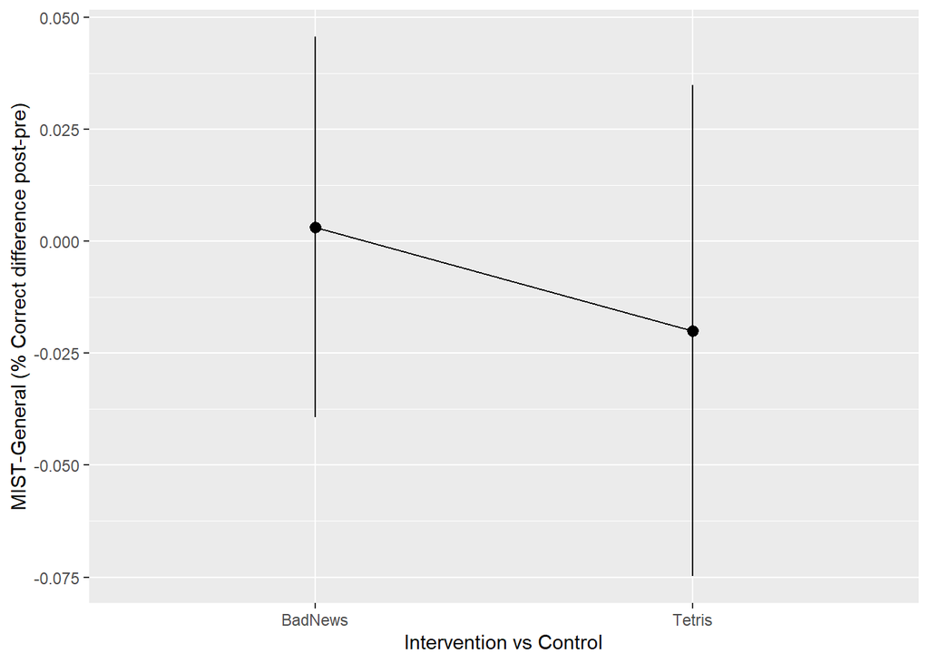

```r
estimate_means(m, by = "Intervention") |>
  ggplot(aes(x=Intervention, y=Mean)) +
  geom_line(aes(group=1)) +
  geom_pointrange(aes(ymin=CI_low, ymax=CI_high)) +
  labs(y="MIST-General (% Correct difference post-pre)", x="Intervention vs Control")
```

## ONLY SELF-IDENTIFIED CONSERVATIVES [ideology affiliation] Intervention vs Control (independent/predictor) & MIST TOTAL (% Correct difference post-pre) (dependent/outcome)

```r
df_conservatives <- df[df$Political_LiberalConservative >= 5 & df$Political_LiberalConservative <= 7, ]

m <- lm(MIST_correct_Diff ~ Intervention,
        data=df_conservatives)

display(estimate_contrasts(m, contrast="Intervention", p_adjust="none"))
```

Marginal Contrasts Analysis

| Level1 | Level2 | Difference | 95% CI | SE | t(54) | p |
| --- | --- | --- | --- | --- | --- | --- |
| Tetris | BadNews | -0.07 | (-0.14, -0.01) | 0.03 | -2.26 | 0.028 |

Marginal contrasts estimated at Intervention p-values are uncorrected.

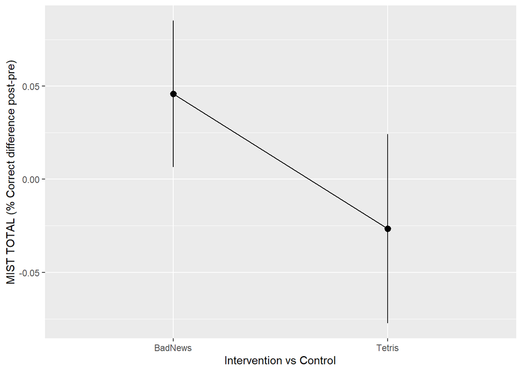

```r
estimate_means(m, by = "Intervention") |>
  ggplot(aes(x=Intervention, y=Mean)) +
  geom_line(aes(group=1)) +
  geom_pointrange(aes(ymin=CI_low, ymax=CI_high)) +
  labs(y="MIST TOTAL (% Correct difference post-pre)", x="Intervention vs Control")
```

## CONFIDENCE [political ideology]

```r
df_long <- df |>
  pivot_longer(cols = starts_with("MIST_Confidence_"),
               names_to = "Category", values_to = "Confidence") |>
  mutate(TestPhase = ifelse(grepl("Pretest", Category), "Pretest", "Posttest"))

# Filter pretest data
df_pre <- filter(df_long, TestPhase == "Pretest")

# Run model
m_pre <- lm(Confidence ~ poly(Political_LiberalConservative, 2) * Category,
            data = filter(df_pre, !is.na(Political_LiberalConservative)))

# Print model summary (this will show the p-values)
summary(m_pre)
```

```
Call:
lm(formula = Confidence ~ poly(Political_LiberalConservative,
    2) * Category, data = filter(df_pre, !is.na(Political_LiberalConservative)))

Residuals:
     Min       1Q   Median       3Q      Max
-0.52036 -0.16918 -0.03385  0.14705  0.72182

Coefficients:
                                                                                     Estimate
(Intercept)                                                                           0.34433
poly(Political_LiberalConservative, 2)1                                              -0.92127
poly(Political_LiberalConservative, 2)2                                               0.65295
CategoryMIST_Confidence_Pretest_fake_covid                                           -0.05533
CategoryMIST_Confidence_Pretest_fake_general                                          0.07941
CategoryMIST_Confidence_Pretest_real_covid                                            0.10461
CategoryMIST_Confidence_Pretest_real_general                                         -0.12869
poly(Political_LiberalConservative, 2)1:CategoryMIST_Confidence_Pretest_fake_covid    1.56262
poly(Political_LiberalConservative, 2)2:CategoryMIST_Confidence_Pretest_fake_covid   -0.26162
poly(Political_LiberalConservative, 2)1:CategoryMIST_Confidence_Pretest_fake_general -1.32728
poly(Political_LiberalConservative, 2)2:CategoryMIST_Confidence_Pretest_fake_general -0.06488
poly(Political_LiberalConservative, 2)1:CategoryMIST_Confidence_Pretest_real_covid   -1.20633
poly(Political_LiberalConservative, 2)2:CategoryMIST_Confidence_Pretest_real_covid   -0.18614
poly(Political_LiberalConservative, 2)1:CategoryMIST_Confidence_Pretest_real_general  0.97099
poly(Political_LiberalConservative, 2)2:CategoryMIST_Confidence_Pretest_real_general  0.51265
                                                                                     Std. Error
(Intercept)                                                                             0.01411
poly(Political_LiberalConservative, 2)1                                                 0.51278
poly(Political_LiberalConservative, 2)2                                                 0.51278
CategoryMIST_Confidence_Pretest_fake_covid                                              0.01996
CategoryMIST_Confidence_Pretest_fake_general                                            0.01996
CategoryMIST_Confidence_Pretest_real_covid                                              0.01996
CategoryMIST_Confidence_Pretest_real_general                                            0.01996
poly(Political_LiberalConservative, 2)1:CategoryMIST_Confidence_Pretest_fake_covid      0.72518
poly(Political_LiberalConservative, 2)2:CategoryMIST_Confidence_Pretest_fake_covid      0.72518
poly(Political_LiberalConservative, 2)1:CategoryMIST_Confidence_Pretest_fake_general    0.72518
poly(Political_LiberalConservative, 2)2:CategoryMIST_Confidence_Pretest_fake_general    0.72518
poly(Political_LiberalConservative, 2)1:CategoryMIST_Confidence_Pretest_real_covid      0.72518
poly(Political_LiberalConservative, 2)2:CategoryMIST_Confidence_Pretest_real_covid      0.72518
poly(Political_LiberalConservative, 2)1:CategoryMIST_Confidence_Pretest_real_general    0.72518
```

[output cut: 40 more lines]

```
CategoryMIST_Confidence_Pretest_real_general                                         ***
poly(Political_LiberalConservative, 2)1:CategoryMIST_Confidence_Pretest_fake_covid   *
poly(Political_LiberalConservative, 2)2:CategoryMIST_Confidence_Pretest_fake_covid
poly(Political_LiberalConservative, 2)1:CategoryMIST_Confidence_Pretest_fake_general .
poly(Political_LiberalConservative, 2)2:CategoryMIST_Confidence_Pretest_fake_general
poly(Political_LiberalConservative, 2)1:CategoryMIST_Confidence_Pretest_real_covid   .
poly(Political_LiberalConservative, 2)2:CategoryMIST_Confidence_Pretest_real_covid
poly(Political_LiberalConservative, 2)1:CategoryMIST_Confidence_Pretest_real_general
poly(Political_LiberalConservative, 2)2:CategoryMIST_Confidence_Pretest_real_general
---
Signif. codes:  0 '***' 0.001 '**' 0.01 '*' 0.05 '.' 0.1 ' ' 1

Residual standard error: 0.2293 on 1305 degrees of freedom
Multiple R-squared:  0.1531,    Adjusted R-squared:  0.144
F-statistic: 16.85 on 14 and 1305 DF,  p-value: < 2.2e-16
```

```r
# Print the summary of the pretest model, including overall significance
summary(m_pre)
```

```
Call:
lm(formula = Confidence ~ poly(Political_LiberalConservative,
    2) * Category, data = filter(df_pre, !is.na(Political_LiberalConservative)))

Residuals:
     Min       1Q   Median       3Q      Max
-0.52036 -0.16918 -0.03385  0.14705  0.72182

Coefficients:
                                                                                     Estimate
(Intercept)                                                                           0.34433
poly(Political_LiberalConservative, 2)1                                              -0.92127
poly(Political_LiberalConservative, 2)2                                               0.65295
CategoryMIST_Confidence_Pretest_fake_covid                                           -0.05533
CategoryMIST_Confidence_Pretest_fake_general                                          0.07941
CategoryMIST_Confidence_Pretest_real_covid                                            0.10461
CategoryMIST_Confidence_Pretest_real_general                                         -0.12869
poly(Political_LiberalConservative, 2)1:CategoryMIST_Confidence_Pretest_fake_covid    1.56262
poly(Political_LiberalConservative, 2)2:CategoryMIST_Confidence_Pretest_fake_covid   -0.26162
poly(Political_LiberalConservative, 2)1:CategoryMIST_Confidence_Pretest_fake_general -1.32728
poly(Political_LiberalConservative, 2)2:CategoryMIST_Confidence_Pretest_fake_general -0.06488
poly(Political_LiberalConservative, 2)1:CategoryMIST_Confidence_Pretest_real_covid   -1.20633
poly(Political_LiberalConservative, 2)2:CategoryMIST_Confidence_Pretest_real_covid   -0.18614
poly(Political_LiberalConservative, 2)1:CategoryMIST_Confidence_Pretest_real_general  0.97099
poly(Political_LiberalConservative, 2)2:CategoryMIST_Confidence_Pretest_real_general  0.51265
                                                                                     Std. Error
(Intercept)                                                                             0.01411
poly(Political_LiberalConservative, 2)1                                                 0.51278
poly(Political_LiberalConservative, 2)2                                                 0.51278
CategoryMIST_Confidence_Pretest_fake_covid                                              0.01996
CategoryMIST_Confidence_Pretest_fake_general                                            0.01996
CategoryMIST_Confidence_Pretest_real_covid                                              0.01996
CategoryMIST_Confidence_Pretest_real_general                                            0.01996
poly(Political_LiberalConservative, 2)1:CategoryMIST_Confidence_Pretest_fake_covid      0.72518
poly(Political_LiberalConservative, 2)2:CategoryMIST_Confidence_Pretest_fake_covid      0.72518
poly(Political_LiberalConservative, 2)1:CategoryMIST_Confidence_Pretest_fake_general    0.72518
poly(Political_LiberalConservative, 2)2:CategoryMIST_Confidence_Pretest_fake_general    0.72518
poly(Political_LiberalConservative, 2)1:CategoryMIST_Confidence_Pretest_real_covid      0.72518
poly(Political_LiberalConservative, 2)2:CategoryMIST_Confidence_Pretest_real_covid      0.72518
poly(Political_LiberalConservative, 2)1:CategoryMIST_Confidence_Pretest_real_general    0.72518
```

[output cut: 40 more lines]

```
CategoryMIST_Confidence_Pretest_real_general                                         ***
poly(Political_LiberalConservative, 2)1:CategoryMIST_Confidence_Pretest_fake_covid   *
poly(Political_LiberalConservative, 2)2:CategoryMIST_Confidence_Pretest_fake_covid
poly(Political_LiberalConservative, 2)1:CategoryMIST_Confidence_Pretest_fake_general .
poly(Political_LiberalConservative, 2)2:CategoryMIST_Confidence_Pretest_fake_general
poly(Political_LiberalConservative, 2)1:CategoryMIST_Confidence_Pretest_real_covid   .
poly(Political_LiberalConservative, 2)2:CategoryMIST_Confidence_Pretest_real_covid
poly(Political_LiberalConservative, 2)1:CategoryMIST_Confidence_Pretest_real_general
poly(Political_LiberalConservative, 2)2:CategoryMIST_Confidence_Pretest_real_general
---
Signif. codes:  0 '***' 0.001 '**' 0.01 '*' 0.05 '.' 0.1 ' ' 1

Residual standard error: 0.2293 on 1305 degrees of freedom
Multiple R-squared:  0.1531,    Adjusted R-squared:  0.144
F-statistic: 16.85 on 14 and 1305 DF,  p-value: < 2.2e-16
```

```r
# Print the p-value for the F-statistic (overall model)
summary(m_pre)$fstatistic
```

```
     value      numdf      dendf
  16.84718   14.00000 1305.00000
```

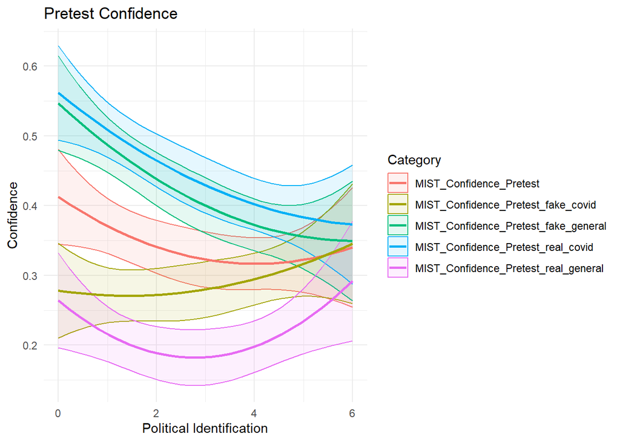

```r
# Predict values
preds_pre <- estimate_relation(m_pre, length=30)

# Plot
ggplot(preds_pre, aes(x=Political_LiberalConservative, y=Predicted, color=Category)) +
  geom_ribbon(aes(ymin=CI_low, ymax=CI_high, fill=Category), alpha=0.1) +
  geom_line(size=1) +
  labs(y="Confidence", x="Political Identification", title="Pretest Confidence") +
  theme_minimal()
```

```r
##___________________________________________________________

# Filter posttest data
df_post <- filter(df_long, TestPhase == "Posttest")

# Run model
m_post <- lm(Confidence ~ poly(Political_LiberalConservative, 2) * Category,
             data = filter(df_post, !is.na(Political_LiberalConservative)))

# Print model summary (this will show the p-values)
summary(m_post)
```

```
Call:
lm(formula = Confidence ~ poly(Political_LiberalConservative,
    2) * Category, data = filter(df_post, !is.na(Political_LiberalConservative)))

Residuals:
     Min       1Q   Median       3Q      Max
-0.54563 -0.17013 -0.03195  0.15759  0.73720

Coefficients:
                                                                                      Estimate
(Intercept)                                                                            0.36919
poly(Political_LiberalConservative, 2)1                                               -0.95887
poly(Political_LiberalConservative, 2)2                                                0.56650
CategoryMIST_Confidence_Posttest_fake_covid                                           -0.04160
CategoryMIST_Confidence_Posttest_fake_general                                          0.10322
CategoryMIST_Confidence_Posttest_real_covid                                            0.10443
CategoryMIST_Confidence_Posttest_real_general                                         -0.16605
poly(Political_LiberalConservative, 2)1:CategoryMIST_Confidence_Posttest_fake_covid    0.86655
poly(Political_LiberalConservative, 2)2:CategoryMIST_Confidence_Posttest_fake_covid   -0.02468
poly(Political_LiberalConservative, 2)1:CategoryMIST_Confidence_Posttest_fake_general -1.87644
poly(Political_LiberalConservative, 2)2:CategoryMIST_Confidence_Posttest_fake_general -0.05907
poly(Political_LiberalConservative, 2)1:CategoryMIST_Confidence_Posttest_real_covid   -0.13667
poly(Political_LiberalConservative, 2)2:CategoryMIST_Confidence_Posttest_real_covid    0.09394
poly(Political_LiberalConservative, 2)1:CategoryMIST_Confidence_Posttest_real_general  1.14655
poly(Political_LiberalConservative, 2)2:CategoryMIST_Confidence_Posttest_real_general -0.01019
                                                                                      Std. Error
(Intercept)                                                                              0.01468
poly(Political_LiberalConservative, 2)1                                                  0.53340
poly(Political_LiberalConservative, 2)2                                                  0.53340
CategoryMIST_Confidence_Posttest_fake_covid                                              0.02076
CategoryMIST_Confidence_Posttest_fake_general                                            0.02076
CategoryMIST_Confidence_Posttest_real_covid                                              0.02076
CategoryMIST_Confidence_Posttest_real_general                                            0.02076
poly(Political_LiberalConservative, 2)1:CategoryMIST_Confidence_Posttest_fake_covid      0.75434
poly(Political_LiberalConservative, 2)2:CategoryMIST_Confidence_Posttest_fake_covid      0.75434
poly(Political_LiberalConservative, 2)1:CategoryMIST_Confidence_Posttest_fake_general    0.75434
poly(Political_LiberalConservative, 2)2:CategoryMIST_Confidence_Posttest_fake_general    0.75434
poly(Political_LiberalConservative, 2)1:CategoryMIST_Confidence_Posttest_real_covid      0.75434
poly(Political_LiberalConservative, 2)2:CategoryMIST_Confidence_Posttest_real_covid      0.75434
poly(Political_LiberalConservative, 2)1:CategoryMIST_Confidence_Posttest_real_general    0.75434
```

[output cut: 40 more lines]

```
CategoryMIST_Confidence_Posttest_real_general                                         ***
poly(Political_LiberalConservative, 2)1:CategoryMIST_Confidence_Posttest_fake_covid
poly(Political_LiberalConservative, 2)2:CategoryMIST_Confidence_Posttest_fake_covid
poly(Political_LiberalConservative, 2)1:CategoryMIST_Confidence_Posttest_fake_general *
poly(Political_LiberalConservative, 2)2:CategoryMIST_Confidence_Posttest_fake_general
poly(Political_LiberalConservative, 2)1:CategoryMIST_Confidence_Posttest_real_covid
poly(Political_LiberalConservative, 2)2:CategoryMIST_Confidence_Posttest_real_covid
poly(Political_LiberalConservative, 2)1:CategoryMIST_Confidence_Posttest_real_general
poly(Political_LiberalConservative, 2)2:CategoryMIST_Confidence_Posttest_real_general
---
Signif. codes:  0 '***' 0.001 '**' 0.01 '*' 0.05 '.' 0.1 ' ' 1

Residual standard error: 0.2385 on 1305 degrees of freedom
Multiple R-squared:  0.1754,    Adjusted R-squared:  0.1665
F-statistic: 19.82 on 14 and 1305 DF,  p-value: < 2.2e-16
```

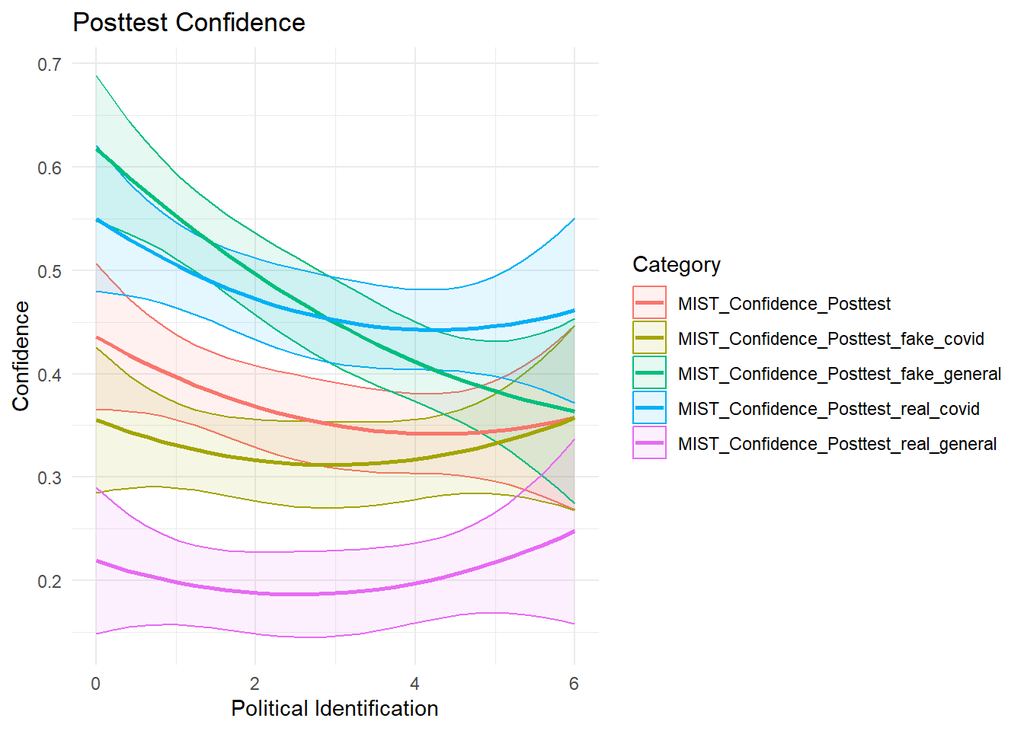

```r
# Predict values
preds_post <- estimate_relation(m_post, length=30)

# Plot
ggplot(preds_post, aes(x=Political_LiberalConservative, y=Predicted, color=Category)) +
  geom_ribbon(aes(ymin=CI_low, ymax=CI_high, fill=Category), alpha=0.1) +
  geom_line(size=1) +
  labs(y="Confidence", x="Political Identification", title="Posttest Confidence") +
  theme_minimal()
```

## CONFIDENCE [intervention vs control] pretest and posttest

```r
df_long <- df |>
  pivot_longer(cols = starts_with("MIST_Confidence_"),
               names_to = "Category", values_to = "Confidence") |>
  mutate(TestPhase = ifelse(grepl("Pretest", Category), "Pretest", "Posttest"))

# Filter pretest data
df_pre <- filter(df_long, TestPhase == "Pretest")

# Run model for pretest, using 'Intervention' instead of political ideology
m_pre <- lm(Confidence ~ Intervention * Category,
            data = filter(df_pre, !is.na(Intervention)))

# Print model summary for pretest
summary(m_pre)
```

```
Call:
lm(formula = Confidence ~ Intervention * Category, data = filter(df_pre,
    !is.na(Intervention)))

Residuals:
    Min      1Q  Median      3Q     Max
-0.4662 -0.1746 -0.0383  0.1534  0.6934

Coefficients:
                                                                Estimate
(Intercept)                                                      0.33410
InterventionTetris                                               0.02350
CategoryMIST_Confidence_Pretest_fake_covid                      -0.02749
CategoryMIST_Confidence_Pretest_fake_general                     0.05232
CategoryMIST_Confidence_Pretest_real_covid                       0.09186
CategoryMIST_Confidence_Pretest_real_general                    -0.11669
InterventionTetris:CategoryMIST_Confidence_Pretest_fake_covid   -0.06619
InterventionTetris:CategoryMIST_Confidence_Pretest_fake_general  0.05927
InterventionTetris:CategoryMIST_Confidence_Pretest_real_covid    0.03270
InterventionTetris:CategoryMIST_Confidence_Pretest_real_general -0.02578
                                                                Std. Error
(Intercept)                                                        0.01874
InterventionTetris                                                 0.02876
CategoryMIST_Confidence_Pretest_fake_covid                         0.02651
CategoryMIST_Confidence_Pretest_fake_general                       0.02651
CategoryMIST_Confidence_Pretest_real_covid                         0.02651
CategoryMIST_Confidence_Pretest_real_general                       0.02651
InterventionTetris:CategoryMIST_Confidence_Pretest_fake_covid      0.04067
InterventionTetris:CategoryMIST_Confidence_Pretest_fake_general    0.04067
InterventionTetris:CategoryMIST_Confidence_Pretest_real_covid      0.04067
InterventionTetris:CategoryMIST_Confidence_Pretest_real_general    0.04067
                                                                t value
(Intercept)                                                      17.825
InterventionTetris                                                0.817
CategoryMIST_Confidence_Pretest_fake_covid                       -1.037
CategoryMIST_Confidence_Pretest_fake_general                      1.974
CategoryMIST_Confidence_Pretest_real_covid                        3.465
CategoryMIST_Confidence_Pretest_real_general                     -4.402
InterventionTetris:CategoryMIST_Confidence_Pretest_fake_covid    -1.627
InterventionTetris:CategoryMIST_Confidence_Pretest_fake_general   1.457
InterventionTetris:CategoryMIST_Confidence_Pretest_real_covid     0.804
InterventionTetris:CategoryMIST_Confidence_Pretest_real_general  -0.634
                                                                Pr(>|t|)
(Intercept)                                                      < 2e-16 ***
InterventionTetris                                              0.413928
CategoryMIST_Confidence_Pretest_fake_covid                      0.299926
CategoryMIST_Confidence_Pretest_fake_general                    0.048612 *
CategoryMIST_Confidence_Pretest_real_covid                      0.000546 ***
CategoryMIST_Confidence_Pretest_real_general                    1.16e-05 ***
InterventionTetris:CategoryMIST_Confidence_Pretest_fake_covid   0.103878
InterventionTetris:CategoryMIST_Confidence_Pretest_fake_general 0.145275
InterventionTetris:CategoryMIST_Confidence_Pretest_real_covid   0.421568
InterventionTetris:CategoryMIST_Confidence_Pretest_real_general 0.526333
---
Signif. codes:  0 '***' 0.001 '**' 0.01 '*' 0.05 '.' 0.1 ' ' 1

Residual standard error: 0.2318 on 1320 degrees of freedom
Multiple R-squared:  0.1293,    Adjusted R-squared:  0.1233
F-statistic: 21.77 on 9 and 1320 DF,  p-value: < 2.2e-16
```

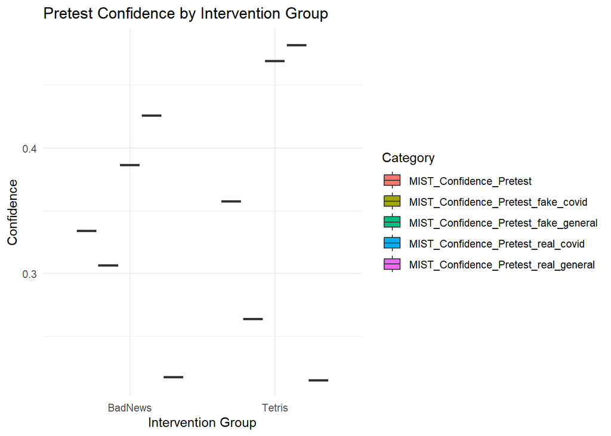

```r
# Predict values for pretest
preds_pre <- estimate_relation(m_pre, length=30)

# Plot for pretest
ggplot(preds_pre, aes(x=Intervention, y=Predicted, fill=Category)) +
  geom_boxplot() +
  labs(y="Confidence", x="Intervention Group", title="Pretest Confidence by Intervention Group") +
  theme_minimal()
```

```r
##___________________________________________________________

# Filter posttest data
df_post <- filter(df_long, TestPhase == "Posttest")

# Run model for posttest, using 'Intervention' instead of political ideology
m_post <- lm(Confidence ~ Intervention * Category,
             data = filter(df_post, !is.na(Intervention)))

# Print model summary for posttest
summary(m_post)
```

```
Call:
lm(formula = Confidence ~ Intervention * Category, data = filter(df_post,
    !is.na(Intervention)))

Residuals:
     Min       1Q   Median       3Q      Max
-0.48042 -0.17482 -0.03479  0.16217  0.78518

Coefficients:
                                                                  Estimate
(Intercept)                                                       0.366632
InterventionTetris                                                0.004905
CategoryMIST_Confidence_Posttest_fake_covid                      -0.047181
CategoryMIST_Confidence_Posttest_fake_general                     0.096139
CategoryMIST_Confidence_Posttest_real_covid                       0.113786
CategoryMIST_Confidence_Posttest_real_general                    -0.162743
InterventionTetris:CategoryMIST_Confidence_Posttest_fake_covid    0.013379
InterventionTetris:CategoryMIST_Confidence_Posttest_fake_general  0.014790
InterventionTetris:CategoryMIST_Confidence_Posttest_real_covid   -0.019199
InterventionTetris:CategoryMIST_Confidence_Posttest_real_general -0.008970
                                                                 Std. Error
(Intercept)                                                        0.019507
InterventionTetris                                                 0.029929
CategoryMIST_Confidence_Posttest_fake_covid                        0.027587
CategoryMIST_Confidence_Posttest_fake_general                      0.027587
CategoryMIST_Confidence_Posttest_real_covid                        0.027587
CategoryMIST_Confidence_Posttest_real_general                      0.027587
InterventionTetris:CategoryMIST_Confidence_Posttest_fake_covid     0.042326
InterventionTetris:CategoryMIST_Confidence_Posttest_fake_general   0.042326
InterventionTetris:CategoryMIST_Confidence_Posttest_real_covid     0.042326
InterventionTetris:CategoryMIST_Confidence_Posttest_real_general   0.042326
                                                                 t value
(Intercept)                                                       18.795
InterventionTetris                                                 0.164
CategoryMIST_Confidence_Posttest_fake_covid                       -1.710
CategoryMIST_Confidence_Posttest_fake_general                      3.485
CategoryMIST_Confidence_Posttest_real_covid                        4.125
CategoryMIST_Confidence_Posttest_real_general                     -5.899
InterventionTetris:CategoryMIST_Confidence_Posttest_fake_covid     0.316
InterventionTetris:CategoryMIST_Confidence_Posttest_fake_general   0.349
InterventionTetris:CategoryMIST_Confidence_Posttest_real_covid    -0.454
InterventionTetris:CategoryMIST_Confidence_Posttest_real_general  -0.212
                                                                 Pr(>|t|)
(Intercept)                                                       < 2e-16 ***
InterventionTetris                                               0.869857
CategoryMIST_Confidence_Posttest_fake_covid                      0.087450 .
CategoryMIST_Confidence_Posttest_fake_general                    0.000508 ***
CategoryMIST_Confidence_Posttest_real_covid                      3.95e-05 ***
CategoryMIST_Confidence_Posttest_real_general                    4.63e-09 ***
InterventionTetris:CategoryMIST_Confidence_Posttest_fake_covid   0.751980
InterventionTetris:CategoryMIST_Confidence_Posttest_fake_general 0.726815
InterventionTetris:CategoryMIST_Confidence_Posttest_real_covid   0.650193
InterventionTetris:CategoryMIST_Confidence_Posttest_real_general 0.832189
---
Signif. codes:  0 '***' 0.001 '**' 0.01 '*' 0.05 '.' 0.1 ' ' 1

Residual standard error: 0.2413 on 1320 degrees of freedom
Multiple R-squared:  0.1509,    Adjusted R-squared:  0.1451
F-statistic: 26.07 on 9 and 1320 DF,  p-value: < 2.2e-16
```

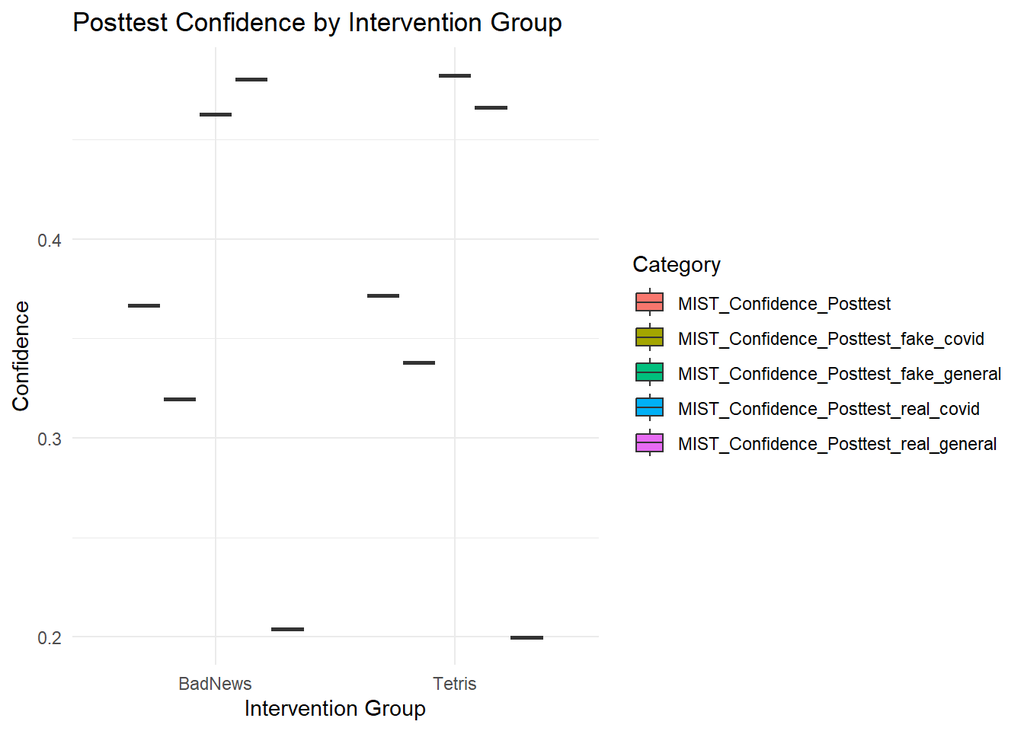

```r
# Predict values for posttest
preds_post <- estimate_relation(m_post, length=30)

# Plot for posttest
ggplot(preds_post, aes(x=Intervention, y=Predicted, fill=Category)) +
  geom_boxplot() +
  labs(y="Confidence", x="Intervention Group", title="Posttest Confidence by Intervention Group") +
  theme_minimal()
```

```r
# Linear model for MIST Confidence difference based on Intervention, Pretest to Posttest
m_intervention <- lm(MIST_Confidence_Posttest - MIST_Confidence_Pretest ~ Intervention,
                     data = df)

# Estimate contrasts (for significance testing between intervention and control)
display(estimate_contrasts(m_intervention, contrast="Intervention", p_adjust="none"))
```

Marginal Contrasts Analysis

| Level1 | Level2 | Difference | 95% CI | SE | t(264) | p |
| --- | --- | --- | --- | --- | --- | --- |
| Tetris | BadNews | -0.02 | (-0.05, 0.02) | 0.02 | -1.02 | 0.307 |

Marginal contrasts estimated at Intervention p-values are uncorrected.

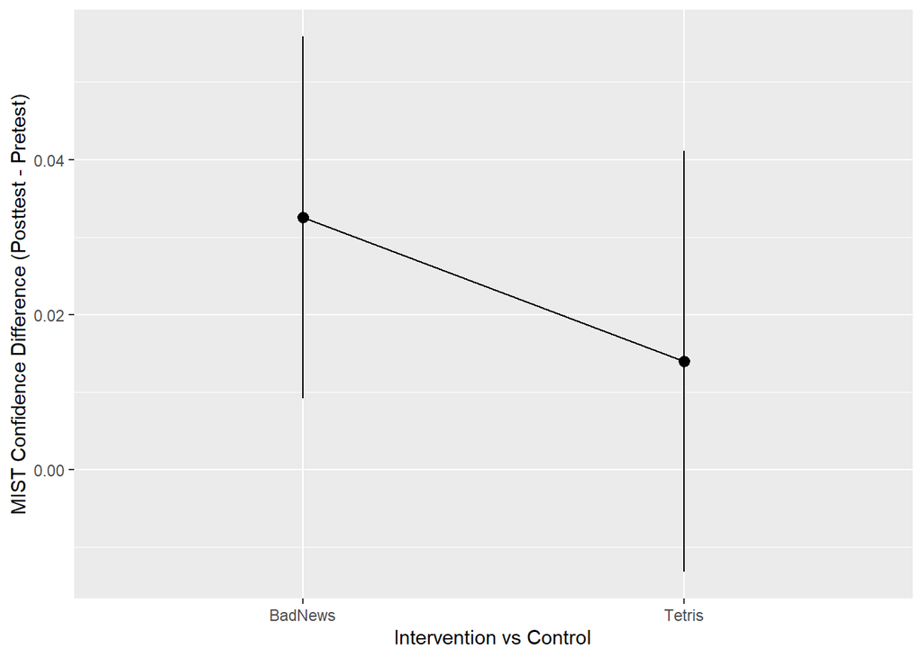

```r
# Estimate means by intervention group
estimate_means(m_intervention, by = "Intervention") |>
  ggplot(aes(x = Intervention, y = Mean)) +
  geom_line(aes(group = 1)) +
  geom_pointrange(aes(ymin = CI_low, ymax = CI_high)) +
  labs(y = "MIST Confidence Difference (Posttest - Pretest)", x = "Intervention vs Control")
```

## confidence posttest intervention vs control

```r
# Categorical
m <- lm((MIST_Confidence_Posttest) ~ Intervention,
        data=df)

display(estimate_contrasts(m, contrast="Intervention", p_adjust="none"))
```

Marginal Contrasts Analysis

| Level1 | Level2 | Difference | 95% CI | SE | t(264) | p |
| --- | --- | --- | --- | --- | --- | --- |
| Tetris | BadNews | 4.90e-03 | (-0.04, 0.05) | 0.02 | 0.22 | 0.824 |

Marginal contrasts estimated at Intervention p-values are uncorrected.

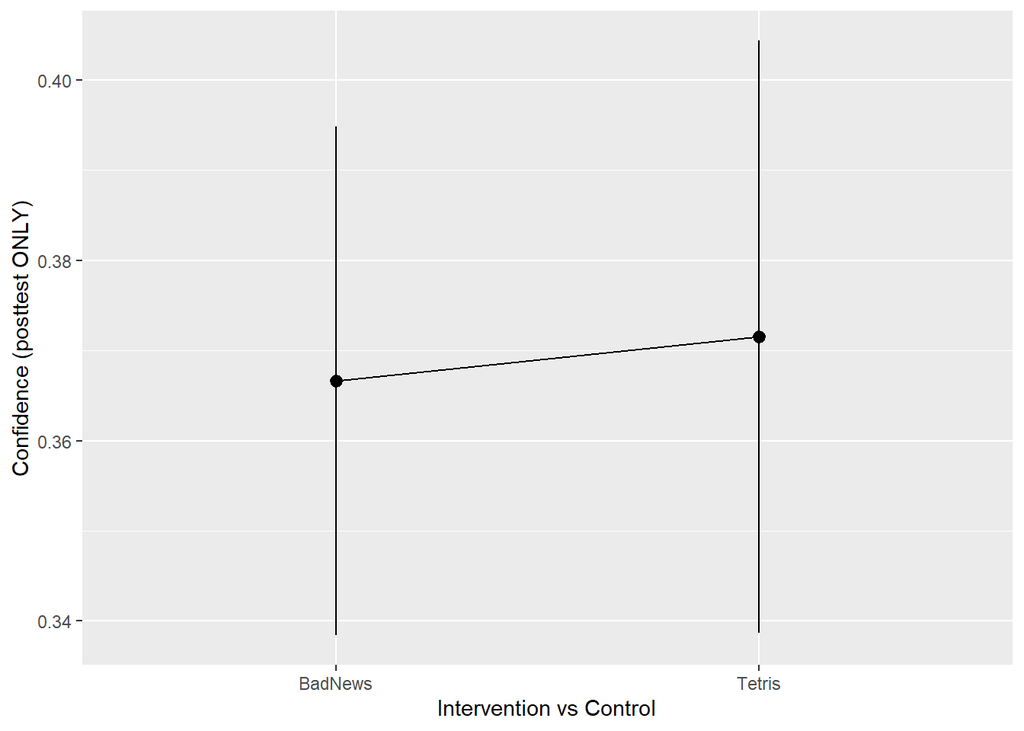

```r
estimate_means(m, by = "Intervention") |>
  ggplot(aes(x=Intervention, y=Mean)) +
  geom_line(aes(group=1)) +
  geom_pointrange(aes(ymin=CI_low, ymax=CI_high)) +
  labs(y="Confidence (posttest ONLY)", x="Intervention vs Control")
```

## t-test intervention group ONLY, pretest vs posttest confidence

```r
# Subset the data for just the BadNews intervention group
df_badnews <- filter(df, Intervention == "BadNews")

# Paired t-test comparing pretest and posttest confidence
t.test(df_badnews$MIST_Confidence_Pretest,
       df_badnews$MIST_Confidence_Posttest,
       paired = TRUE)
```

```
    Paired t-test

data:  df_badnews$MIST_Confidence_Pretest and df_badnews$MIST_Confidence_Posttest
t = -2.5985, df = 152, p-value = 0.01028
alternative hypothesis: true mean difference is not equal to 0
95 percent confidence interval:
 -0.057262921 -0.007796992
sample estimates:
mean difference
    -0.03252996
```

## CRITERION overall difference post-pre intervention vs control

```r
# Create a new column for the overall criterion post-pre difference (averaging covid and general)
df$Criterion_Difference <- (df$MIST_criterion_Diff_covid + df$MIST_criterion_Diff_general) / 2

# Linear Model for Criterion Difference (Post - Pre) by Intervention
m_criterion_diff <- lm(Criterion_Difference ~ Intervention, data = df)

# Displaying the estimated contrasts for the 'Intervention' variable
display(estimate_contrasts(m_criterion_diff, contrast = "Intervention", p_adjust = "none"))
```

Marginal Contrasts Analysis

| Level1 | Level2 | Difference | 95% CI | SE | t(264) | p |
| --- | --- | --- | --- | --- | --- | --- |
| Tetris | BadNews | -0.08 | (-0.17, 0.00) | 0.04 | -1.86 | 0.063 |

Marginal contrasts estimated at Intervention p-values are uncorrected.

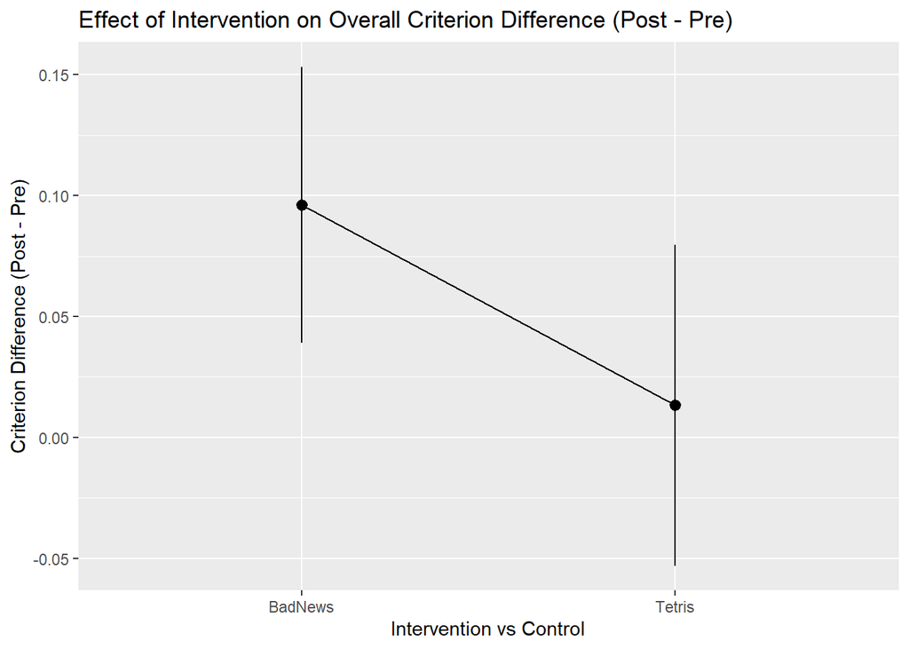

```r
# Estimate means by 'Intervention' group
estimate_means(m_criterion_diff, by = "Intervention") |>
  ggplot(aes(x = Intervention, y = Mean)) +
  geom_line(aes(group = 1)) +
  geom_pointrange(aes(ymin = CI_low, ymax = CI_high)) +
  labs(y = "Criterion Difference (Post - Pre)", x = "Intervention vs Control") +
  ggtitle("Effect of Intervention on Overall Criterion Difference (Post - Pre)")
```